# Análisis Estadístico de Enfermedades en el Corazón

Pablo César Rodríguez Aguayo

Marzo 14, 2019

# **Parte I**: Introducción

## Heart Disease UCI (Enfermedades del Corazón UCI)

Esta base de datos contiene 76 atributos, pero todos los experimentos publicados se refieren al uso de un subconjunto de 14 de ellos. En particular, la base de datos de Cleveland es la única que ha sido utilizada por los investigadores de Machine Learning hasta la fecha. El campo “objetivo” se refiere a la presencia de una enfermedad cardíaca en el paciente. Es un valor entero de 0 (sin presencia) a 4. Los experimentos con la base de datos de Cleveland se han concentrado en simplemente intentar distinguir la presencia (valores 1,2,3,4) de la ausencia (valor 0). Los nombres y números de seguridad social de los pacientes se eliminaron recientemente de la base de datos y se reemplazaron con valores ficticios.

## Problema Presentado

Dentro de la perspectiva social-sanitaria uno de los mayores retos que enfrentan las organizaciones de salud es la prestación de servicios los cuales permitan al paciente un costo bajo así como accesibilidad, con una calidad superior la cual garantice un diagnóstico objetivo. Un diagnóstico preciso comprende una toma de decisiones correcta la cual permita generar un diagnostico preciso para el paciente. Una decisión medica tomada de una forma no adecuada puede conducir a problemas mayores de salud donde cada vez se vuelven más costosos y difíciles de tratar, ya en última instancia pueden traer al paciente consecuencias desastrosas incluso llegando a la muerte. Habitualmente, las decisiones tomadas por el personal clínico a menudo son tomadas basándose en la intuición de los médicos y experiencia en lugar de las observaciones estadísticas de la información presentada, lo cual termina por llevar a errores de tratamiento, costos excesivos y efectos en la calidad de los servicios médicos de los pacientes.

## Significado del Diagnóstico

El diagnóstico de enfermedad cardíaca se realiza mediante una combinación de signos clínicos y resultados de pruebas. Los tipos de pruebas que se realizarán se elegirán en función de lo que el médico cree que está pasando, que va desde los electrocardiogramas y las tomografías computarizadas (TC) cardiacas hasta las pruebas de sangre y las pruebas de esfuerzo con ejercicios.

## Alcance del Estudio

Para propositos de esta investigación, se pretende realizar un análsis exploratorio de los factores que influyen sobre las enfermedades cardiacas. Lo cual permtirá posteriormente aplicar diversas técnicas de minería de datos para descubrir patrones dentro de los datos que nos permitan obtener mediciones y descripciones de los datos a través de la estadística descriptiva.

## Análisis Exploratorio de Datos

El análisis exploratorio de datos permitirá resumir las características que rodean el fenómeno en cuestión. La importancia del análisis exploratorio permite proporcionar y definir la percepcion del conjunto de datos utilizado. Permtiendo definir los objetivos a través del análisis de los datos mediante resumenes numéricos los cuales se enfocan en el aspecto estadístico. De igual manera, permiten enfocarse en los objetivos de la investigacion a través de la delimitación de los datos no necesarios.

## Recolección de Datos y Preprocesamiento

La recolección de datos y preprocesamiento estuvo a cargo de:

1. Hungarian Institute of Cardiology. Budapest: Andras Janosi, M.D.
2. University Hospital, Zurich, Switzerland: William Steinbrunn, M.D.
3. University Hospital, Basel, Switzerland: Matthias Pfisterer, M.D.
4. V.A. Medical Center, Long Beach and Cleveland Clinic Foundation: Robert Detrano, M.D., Ph.D.

Siendo donado por: David W. Aha (aha ‘@’ ics.uci.edu) (714) 856-8779

Por lo que se desconocen los métodos de recolección y preprocesamiento empleados.

# **Parte II**: Análisis Exploratorio

## Análisis de las Características

### Descripción

Dentro de las características del conjunto de datos, se presentan las siguientes:

### Cabecera

Principio del Conjunto de Datos

| age | sex | cp | trestbps | chol | fbs | restecg | thalach | exang | oldpeak | slope | ca | thal | target |
| --- | --- | --- | --- | --- | --- | --- | --- | --- | --- | --- | --- | --- | --- |
| 63 | 1 | 3 | 145 | 233 | 1 | 0 | 150 | 0 | 2.3 | 0 | 0 | 1 | 1 |
| 37 | 1 | 2 | 130 | 250 | 0 | 1 | 187 | 0 | 3.5 | 0 | 0 | 2 | 1 |
| 41 | 0 | 1 | 130 | 204 | 0 | 0 | 172 | 0 | 1.4 | 2 | 0 | 2 | 1 |
| 56 | 1 | 1 | 120 | 236 | 0 | 1 | 178 | 0 | 0.8 | 2 | 0 | 2 | 1 |
| 57 | 0 | 0 | 120 | 354 | 0 | 1 | 163 | 1 | 0.6 | 2 | 0 | 2 | 1 |
| 57 | 1 | 0 | 140 | 192 | 0 | 1 | 148 | 0 | 0.4 | 1 | 0 | 1 | 1 |

### Cola

Final del Conjunto de Datos

|  | age | sex | cp | trestbps | chol | fbs | restecg | thalach | exang | oldpeak | slope | ca | thal | target |
| --- | --- | --- | --- | --- | --- | --- | --- | --- | --- | --- | --- | --- | --- | --- |
| 298 | 59 | 1 | 0 | 164 | 176 | 1 | 0 | 90 | 0 | 1.0 | 1 | 2 | 1 | 0 |
| 299 | 57 | 0 | 0 | 140 | 241 | 0 | 1 | 123 | 1 | 0.2 | 1 | 0 | 3 | 0 |
| 300 | 45 | 1 | 3 | 110 | 264 | 0 | 1 | 132 | 0 | 1.2 | 1 | 0 | 3 | 0 |
| 301 | 68 | 1 | 0 | 144 | 193 | 1 | 1 | 141 | 0 | 3.4 | 1 | 2 | 3 | 0 |
| 302 | 57 | 1 | 0 | 130 | 131 | 0 | 1 | 115 | 1 | 1.2 | 1 | 1 | 3 | 0 |
| 303 | 57 | 0 | 1 | 130 | 236 | 0 | 0 | 174 | 0 | 0.0 | 1 | 1 | 2 | 0 |

El conjunto de datos está conformado por 14 características y 303 observaciones.

## Máximos y Mínimos

Como se ha observado, el conjunto de datos tiene un número considerable de valores por lo que una de las metas es describir estas características y obtener una conclusión. El uso de máximos y mínimos permite el cálculo de otras medidas como el rango el cual se verá posteriormente. Además permite determinar los valores atípicos dentro del conjunto de datos, ya sean los valores atípicos menores o mayores.

### Máximos

Se define como el valor matemático mayor en el conjunto de datos.

Valores Máximos Obtenidos

|  | General | Hombre | Mujer |
| --- | --- | --- | --- |
| Edad | 77.0 | 77.0 | 76.0 |
| Presión Arterial | 200.0 | 192.0 | 200.0 |
| Colesterol | 564.0 | 353.0 | 564.0 |
| Ritmo Cardíaco | 202.0 | 202.0 | 192.0 |
| Depresión ST | 6.2 | 5.6 | 6.2 |

**Comentarios:** Cabe destacar que de lo anterior visto, la *edad* máxima es perteneciente a los hombres por un año. En cuanto a *presión arterial*, se puede ver que el valor mayor corresponde a una mujer tomando el valor de 200, siendo el máximo en hombres menor por 8 unidades. Así mismo pasa con el *colesterol*, siendo el valor máximo encontrado en el subconjunto de las mujeres tomando el valor de 564 y en hombres de 353. Dada la naturaleza aún no estudiada del colesterol, hasta este punto pudiera ser que el colesterol máximo encontrado es un valor atípico. Respecto al *ritmo cardiaco*, se puede apreciar que es mayor en los hombres con un valor de 202, mientras que en mujeres es 10 unidades menor. Por último, se puede ver que en la depresión post-entrenamiento es ligeramente mayor en mujeres por 0.6, tomando las mujeres el valor máximo nuevamente. Hasta este punto, basandose en los aspectos analizados se puede ver que las mujeres tienen los valores máximos en tres de cinco características analizadas, siendo una de ellas un probable valor atípico.

### Mínimos

Se define como el valor matemático menor en el conjunto de datos.

Valores Mínimos Obtenidos

|  | General | Hombre | Mujer |
| --- | --- | --- | --- |
| Edad | 29 | 29 | 34 |
| Presión Arterial | 94 | 94 | 94 |
| Colesterol | 126 | 126 | 141 |
| Ritmo Cardíaco | 71 | 71 | 96 |
| Depresión ST | 0 | 0 | 0 |

**Comentarios:** De acuerdo a los valores mínimos, respecto a la *edad* podemos decir que siendo el valor mínimo perteneciente a un hombre con 29 años y el valor máximo a un hombre igualmente, se puede decir que es más ámplio el rango de edades en los varones. Para este caso, la *presión arterial*, presentó un caso con un valor mínimo de 94 tanto para hombres como para mujeres. Para el *colesterol* se puede ver que el valor mínimo se encuentra en el subconjunto de los hombres, con un valor de 126, mientras que las mujeres poseen un valor mínimo de 141. Para el caso del *ritmo cardiaco*, la presencia en hombres es con un valor mínimo de 71, mientras que en el subconjunto de las mujeres es de 96. Por último, se puede ver que para la depresión post-entrenamiento, el valor para todos es 0, lo cual puede ser un posible valor atípico encontrado dentro del conjunto de datos.

## Cuartiles, Percentiles y Valores Atípicos

### Cuartiles

En términos generales, los cuartiles dividen el conjunto de datos en cuatro partes iguales, con observaciones sobre el tercer cuartil que constituyen el cuarto superior de los datos del conjunto, siendo el segundo cuartil idéntico a la mediana, y el primer cuartil separado al cuarto más bajo de los tres cuartos superiores. Los valores comunmente esperados se encuentran entre el primer cuartil y el tercero, mientras que los valores atípicos se encuentran ya sea por encima del tercer cuartil o bien por debajo del primer cuartil. A continuación se hace el análisis de los cuartiles de los atributos.

Cuartiles de las Mujeres

|  | Edad | Presión Arterial | Colesterol | Ritmo Cardíaco | Depresión ST |
| --- | --- | --- | --- | --- | --- |
| 0% | 34.00 | 94 | 141.00 | 96.00 | 0.0 |
| 25% | 49.75 | 120 | 214.75 | 141.25 | 0.0 |
| 50% | 57.00 | 131 | 253.00 | 157.00 | 0.6 |
| 75% | 63.00 | 140 | 296.75 | 165.00 | 1.4 |
| 100% | 76.00 | 200 | 564.00 | 192.00 | 6.2 |

Cuartiles de los Hombres

|  | Edad | Presión Arterial | Colesterol | Ritmo Cardíaco | Depresión ST |
| --- | --- | --- | --- | --- | --- |
| 0% | 29.0 | 94 | 126 | 71 | 0.0 |
| 25% | 47.0 | 120 | 208 | 132 | 0.0 |
| 50% | 54.0 | 130 | 235 | 151 | 0.8 |
| 75% | 59.5 | 140 | 268 | 168 | 1.8 |
| 100% | 77.0 | 192 | 353 | 202 | 5.6 |

Cuartiles de los Pacientes en General

|  | Edad | Presión Arterial | Colesterol | Ritmo Cardíaco | Depresión ST |
| --- | --- | --- | --- | --- | --- |
| 0% | 29.0 | 94 | 126.0 | 71.0 | 0.0 |
| 25% | 47.5 | 120 | 211.0 | 133.5 | 0.0 |
| 50% | 55.0 | 130 | 240.0 | 153.0 | 0.8 |
| 75% | 61.0 | 140 | 274.5 | 166.0 | 1.6 |
| 100% | 77.0 | 200 | 564.0 | 202.0 | 6.2 |

### Percentiles

Del mismo modo, un conjunto de datos se puede dividir aún más finamente usando percentiles; el percentil 99 separa el 1% más alto del 99% inferior, y así sucesivamente. A menos que el número de observaciones sea múltiplo de 100.

**Nota:** El percentil en la posición 50, el segundo cuartil, la mediana y el quinto decil son el mismo valor el cual está representado mediante la siguiente fórmula.

$$P_{50} = \tilde{x} = Q_2 = D_5$$
A continuación analizaremos los percentiles desde la perspectiva de un deciles.

Percentiles de las Mujeres

|  | Edad | Presión Arterial | Colesterol | Ritmo Cardíaco | Depresión ST |
| --- | --- | --- | --- | --- | --- |
| 10% | 42.0 | 109.0 | 197.0 | 121.5 | 0.0 |
| 20% | 46.0 | 120.0 | 209.0 | 133.0 | 0.0 |
| 30% | 51.0 | 121.0 | 224.0 | 144.0 | 0.0 |
| 40% | 54.0 | 130.0 | 240.0 | 152.0 | 0.2 |
| 50% | 57.0 | 131.0 | 253.0 | 157.0 | 0.6 |
| 60% | 59.0 | 136.0 | 268.0 | 160.0 | 0.9 |
| 70% | 62.0 | 140.0 | 285.5 | 163.0 | 1.2 |
| 80% | 64.0 | 146.0 | 305.0 | 169.0 | 1.5 |
| 90% | 66.5 | 157.5 | 335.0 | 172.0 | 2.0 |
| 100% | 76.0 | 200.0 | 564.0 | 192.0 | 6.2 |

Percentiles de los Hombres

|  | Edad | Presión Arterial | Colesterol | Ritmo Cardíaco | Depresión ST |
| --- | --- | --- | --- | --- | --- |
| 10% | 42 | 110 | 185.6 | 113.6 | 0.0 |
| 20% | 45 | 120 | 203.2 | 127.2 | 0.0 |
| 30% | 49 | 120 | 213.8 | 140.0 | 0.0 |
| 40% | 52 | 125 | 227.4 | 144.0 | 0.4 |
| 50% | 54 | 130 | 235.0 | 151.0 | 0.8 |
| 60% | 57 | 132 | 247.0 | 158.0 | 1.2 |
| 70% | 59 | 140 | 260.0 | 163.0 | 1.6 |
| 80% | 61 | 142 | 275.8 | 171.0 | 2.0 |
| 90% | 65 | 152 | 299.0 | 178.4 | 2.8 |
| 100% | 77 | 192 | 353.0 | 202.0 | 5.6 |

Percentiles de los Pacientes en General

|  | Edad | Presión Arterial | Colesterol | Ritmo Cardíaco | Depresión ST |
| --- | --- | --- | --- | --- | --- |
| 10% | 42 | 110 | 188.0 | 116.0 | 0.00 |
| 20% | 45 | 120 | 204.0 | 130.0 | 0.00 |
| 30% | 50 | 120 | 217.6 | 140.6 | 0.00 |
| 40% | 53 | 126 | 230.0 | 146.0 | 0.38 |
| 50% | 55 | 130 | 240.0 | 153.0 | 0.80 |
| 60% | 58 | 134 | 254.0 | 159.0 | 1.12 |
| 70% | 59 | 140 | 268.0 | 163.0 | 1.40 |
| 80% | 62 | 144 | 285.2 | 170.0 | 1.90 |
| 90% | 66 | 152 | 308.8 | 176.6 | 2.80 |
| 100% | 77 | 200 | 564.0 | 202.0 | 6.20 |

### Valores Atípicos

Se definen como los valores mucho mayores o menores que los demás valores en el conjunto de datos. O bien, se puede definir como el valor que radica por fuera del conjunto de datos establecido las cuales se distinguen por su distancia a los valores normales.

#### Regla del Pulgar

Siendo una práctica común la *regla del pulgar*, consiste en designar un valor atípico en base a la experiencia obtenida. Para esto, los valores atípicos se calculan mediante dos fórmulas. La primera permite calcular los valores atípicos mínimos, es decir los valores que están por debajo de lo esperado, para esto se emplea la siguiente fórmula:

$$V_{ai} = Q_1 - 1.5*IQR$$
Donde:

- $V_{ai}$ son los valores atípicos inferiores.
- $Q_1$ es el valor del cuartil 1.
- $IQR$ es el valor intercuartil.

Mientras que para calcular los valores atípicos por encima de lo esperado, se emplea la siguiente fórmula:

$$V_{as} = Q_3 + 1.5*IQR$$

Donde:

- $V_{as}$ son los valore atípicos superiores.
- $Q_3$ es el valor del cuartil 3.
- $IQR$ es el valor intercuartil.

Si bien estas medidas no son utilizadas como la forma adecuada para calcular los valores atípicos, dentro de la industrial son ampliamente aceptadas. Sin embargo, estos métodos solo son usados si el analista de datos es considerado de grado midlevel o senior. Para este caso se utilizará el diagrama de caja para ver la distribución de los datos. Para visualizar los valores atípicos se utilizará el diagrama de caja, este permitirá ver el comportamiento dentro del atributo de los datos.

### Rango

El rango permite conocer la diferencia entre el valor máximo y mínimo de la característica seleccionada. Esta medida es considerada como medida de dispersión y permite conocer el intervalo que se haya entre la distribución. Se calcula mediante la siguiente fórmula:

$$R_{var} = max(x) - min(x)$$

### Conlusiones Generales

A continuación se realizará un análisis para las características: edad y presión arterial. Mostrando los valores mínimos, máximo, rango segundo cuartil, obteniendo un breve análisis de los datos obtenidos.

#### Edad

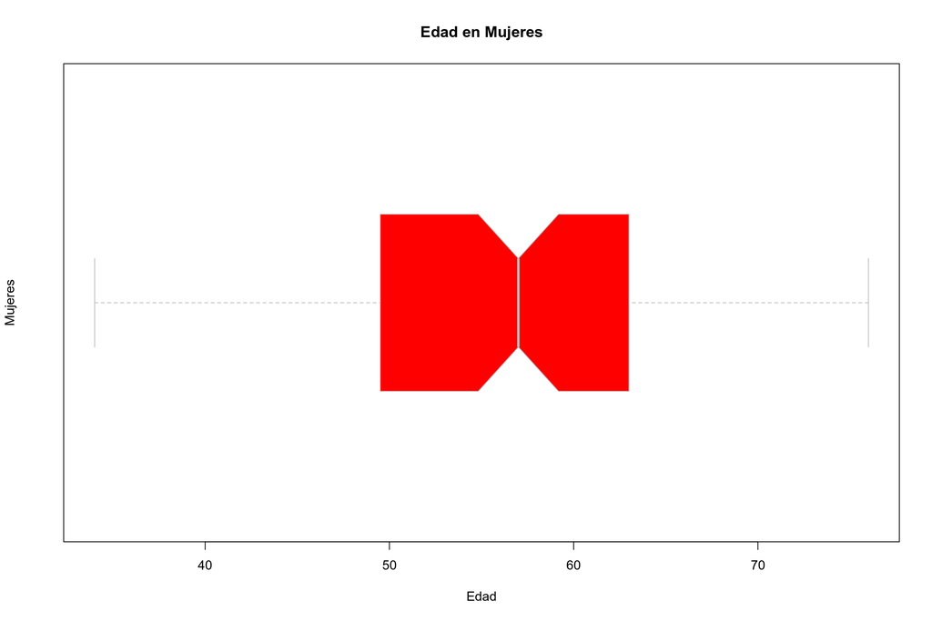

**Comentarios:** De acuerdo a la gráfica anterior se puede apreciar que el valor mínimo está en 34 mientras que su máximo es de 76, con un rango de 42. A su vez se puede apreciar que no hay valores atípicos y que su segundo cuartil es de 57.

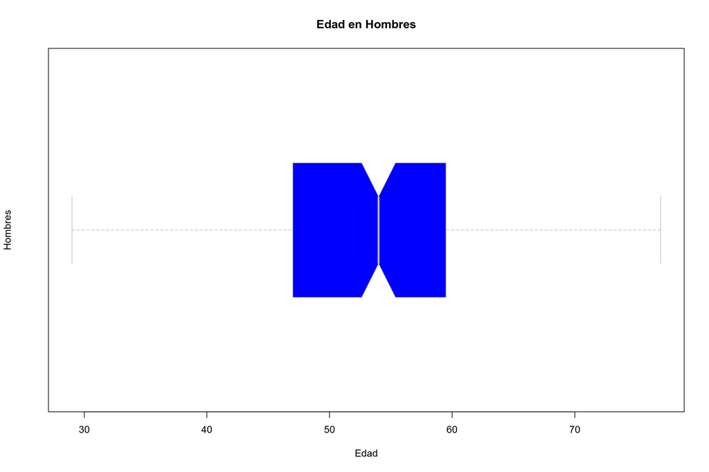

**Comentarios:** Para el conjunto de los hombres se puede apreciar un valor mínimo de 29 y un máximo de 77, donde su rango es de 48. A su vez se puede apreciar que no hay valores atípicos y que su segundo cuartil es de 54, esto debido al mayor rango de los datos.

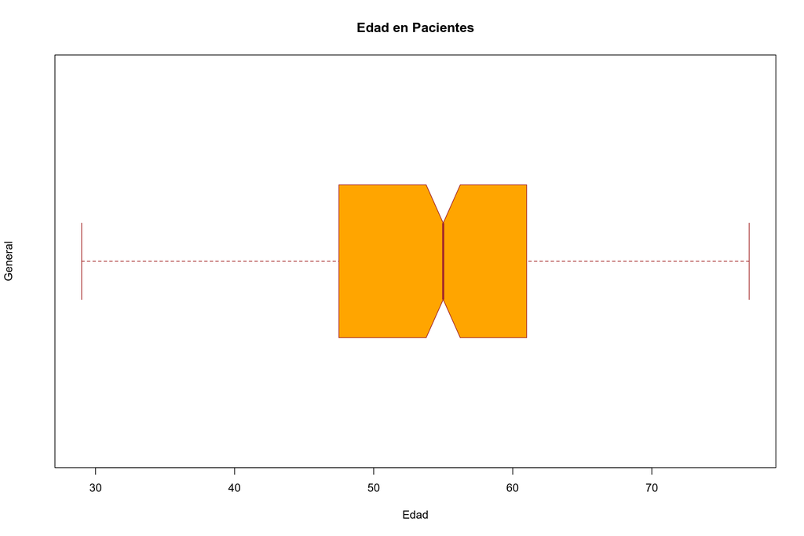

#### Presión Arterial

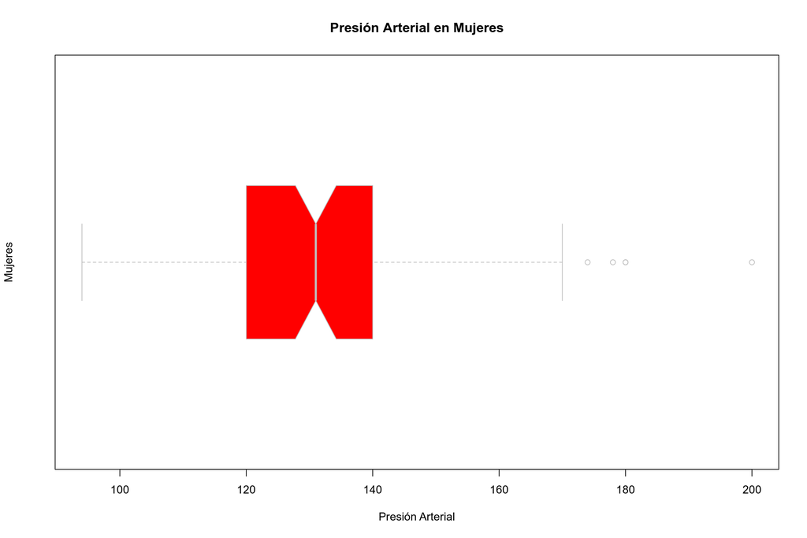

**Comentarios:** En el subconjunto de las mujeres se puede apreciar un valor mínimo de 94 y un máximo de 200, donde su rango es de 106. Presentando valores atípicos despues del tercer quartil y con segundo cuartil de 131 indicando la mitad de los datos.

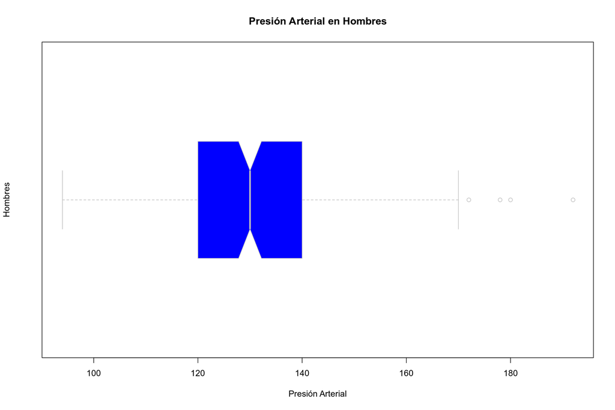

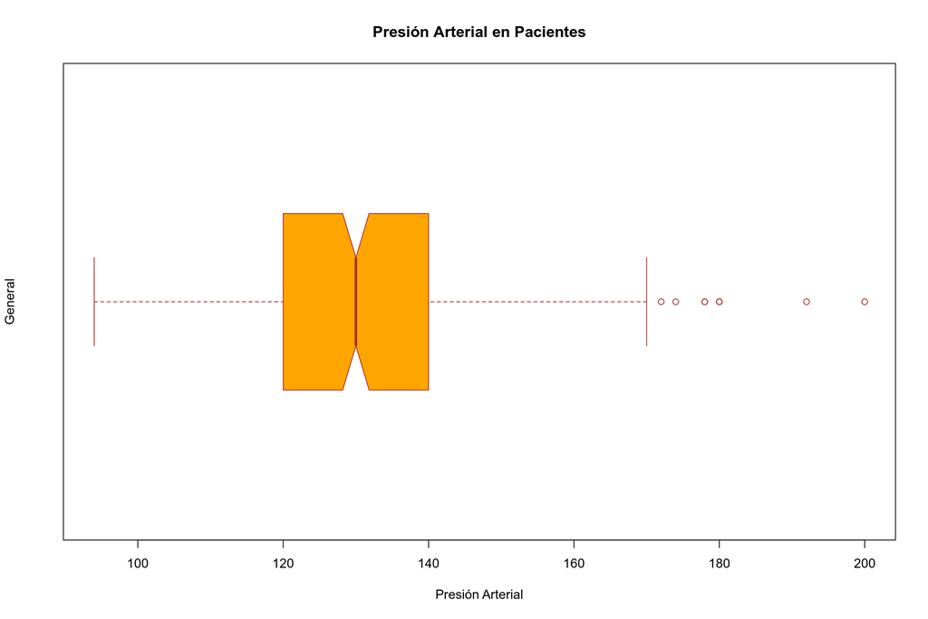

**Comentarios:** Por último, en el conjunto general se puede ver un valor mínimo de 94 y un máximo de 200 con un rango de 106. Presentando valores atípicos después del tercer cuartil y un segundo cuartil de 130.

## Medidas de Tendencia Central

Las medidas de tendencia central permiten obtener indicadores preeliminares que brindan una interpretación numérica de las medidas obtenidas.

### Media

Primer momento alrededor del cero es la media o valor esperado de la variable aleatoria y se denota por $\mu$. La media de una variable aleatoria se considera como una cantidad numérica alrededor de la cual los valores de la variable aleatoria tienden a agruparse. Por lo tanto, la media es una medida de tendencia central. Para el cálculo de la media se utiliza:

$$\bar{x}=\frac{1}{n}\sum_{i=1}^n x_i$$

### Mediana

La mediana en un conjunto de datos es el valor medio cuando los valores son ordenados de manera ascendente o descendente. Igualmente, en este punto será calculada la mediana para futuras referencias, si $n$ es par entonces se calcula mediante:

$$\tilde{x} = x_{(n + 1)/2}$$

Por otro lado si $n$ es impar se calcula:

$$\tilde{x} = x_{(n + 1)/2} + x_{n/2}$$

### Moda

La moda es un término estadístico que se refiere al número que aparece con mayor frecuencia en un conjunto de números. Esta se encuentra al recopilar y organizar datos para contar la frecuencia de cada resultado. Donde radica sobre su recuento más alto de ocurrencias del conjunto, igualmente se le conoce como el valor modal.

$$Varlor\text{ } repetido\text{ } más\text{ } frecuente$$

### Conclusiones Generales

#### Colesterol

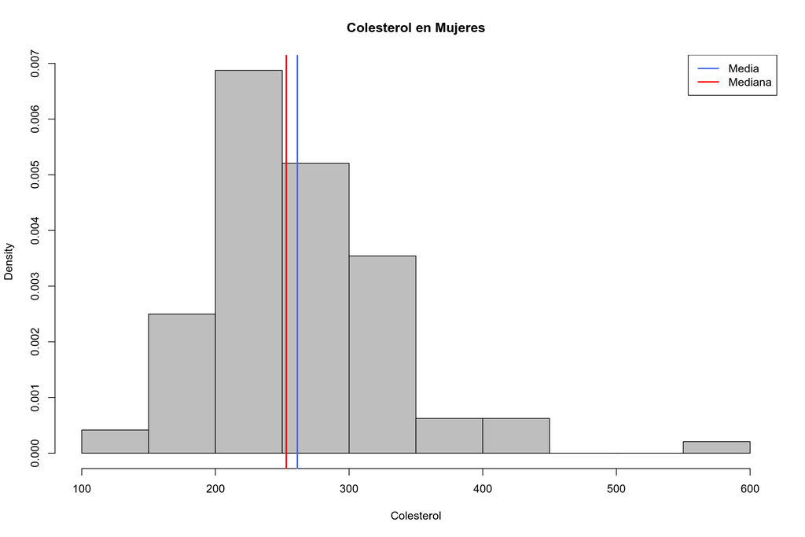

| Media | Mediana |
| --- | --- |
| 261.3021 | 253 |

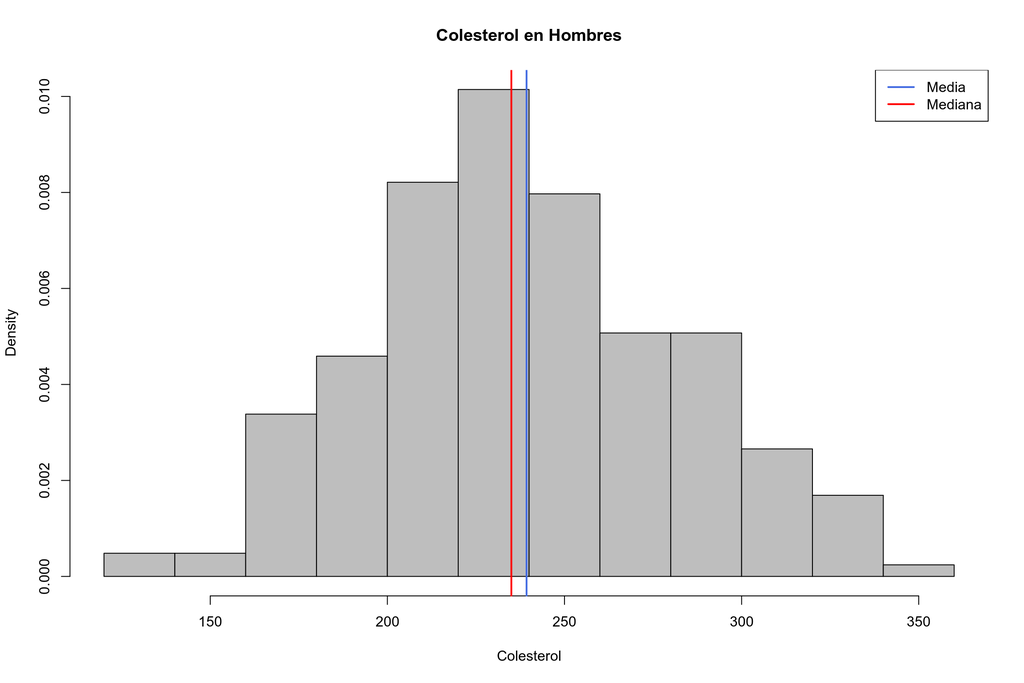

| Media | Mediana |
| --- | --- |
| 239.2899 | 235 |

**Comentarios:** Para esta gráfica se puede apreciar que se obtuvo una mediana media aún más cercanas, donde la media tuvo un valor de 239.28, por otro lado la mediana tuvo un valor de 235. Se puede observar que la diferencia entre ambas medidas sólo fue de 4.28 unidades. Cabe mencionar que esta gráfica se parece más a la distribución normal, la cual será vista posteriormente.

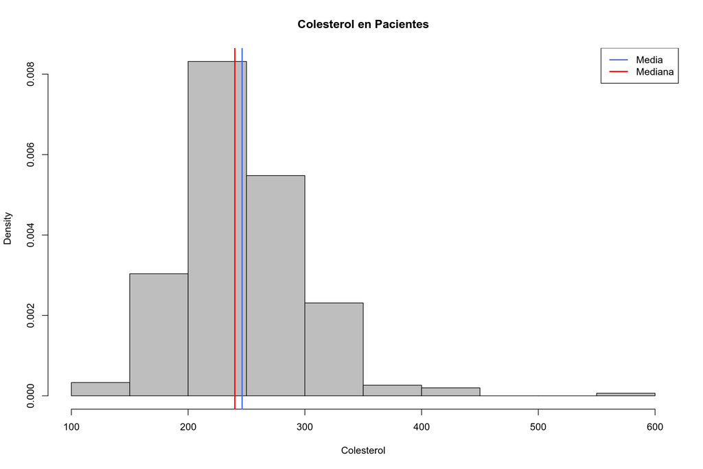

Media y Mediana del Colesterol en Pacientes en General

| Media | Mediana |
| --- | --- |
| 246.264 | 240 |

**Comentarios:** A partir del conjunto de datos en general, se puede apreciar que de acuerdo a la media la mediana es un valor por debajo por sólo 6.26 unidades. Donde la media fue superior en los tres casos presentados.

## Medidas de Dispersión

Las medidas distribución, permiten determinar que tan estirados o compactos están los datos del conjunto. Se puede ver que las medidas de dispersión estadística son la varianza y la desviación estándar son las más comunmente usadas. Estas medidas de dispersión contrastan la ubicación o tendencia central de los datos utilizados.

### Varianza

El segundo momento central,alrededor de la media, recibe el nombre de varianza de la variable aleatoria. La varianza de una variable aleatoria es una medida de la dispersión de la distribución de probabilidad de esta. La varianza puede representarse mediante la siguiente fórmula:

$$s^{2}=\frac{1}{N-1}\sum_{i=1}^N(x_i-\bar{x})^2$$

### Desviación Estándar

La desviación estándar es una medida estadística muestra la dispersión de un conjunto de datos en relación con su media y se calcula como la raíz cuadrada de la varianza. El cálculo realizado a través de la *varianza* permite determinar la variación entre cada punto de datos en relación con la media. Si los puntos de datos están más alejados de la media, hay una mayor desviación dentro del conjunto de datos; por lo tanto, cuanto más dispersos estén los datos, mayor será la desviación estándar. Su representación es la siguiente:

$$s=\sqrt{\frac{1}{N-1}\sum_{i=1}^N(x_i-\bar{x})^2}$$
O bien:
$$s=\sqrt{s^2}$$

A continuación se realizará un análisis del ritmo cardiáco máximo alcanzado, donde se analizarán las medidas de dispersión y de tendencia central.

#### Ritmo Cardiáco Máximo Alcanzado

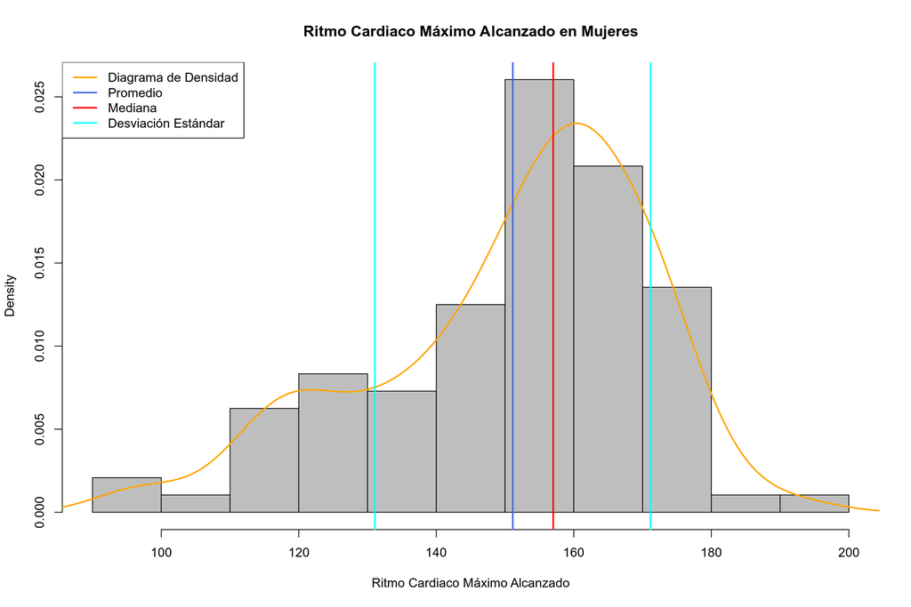

Medidas de Tendencia Central y Dispersión en Mujeres

| Media | Mediana | Desviación Estándar |
| --- | --- | --- |
| 151.125 | 157 | 20.04797 |

**Comentarios:** La desviación estándar ayuda a determinar el tamaño de la dispersión de los datos en comparación con el valor medio. A medida que aumenta la variación, se producen más variaciones en los valores de los datos, y puede haber una brecha mayor entre un valor de datos y otro. Para este caso se puede ver que hay una desviación estándar de 20.04, lo cual indica una dispersión respecto a los datos amplia.

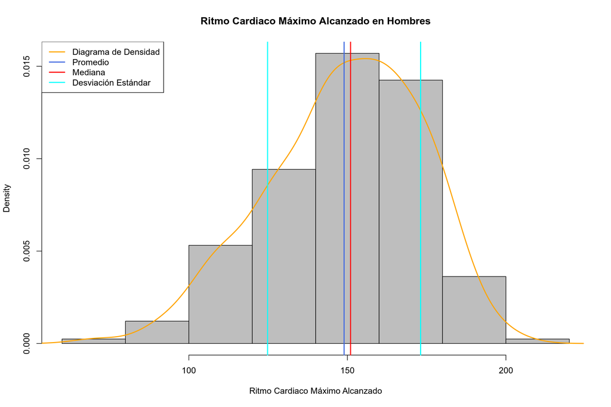

Medidas de Tendencia Central y Dispersión en Hombres

| Media | Mediana | Desviación Estándar |
| --- | --- | --- |
| 148.9614 | 151 | 24.13088 |

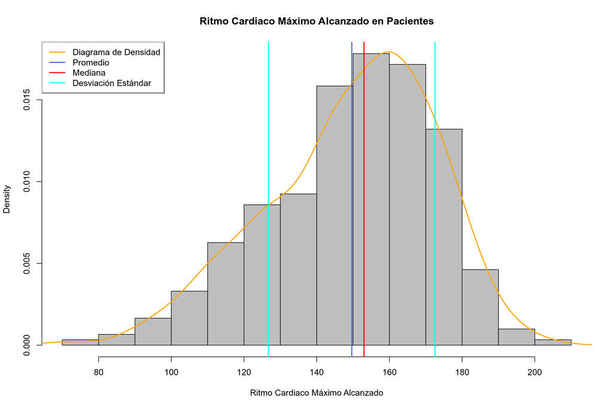

Medidas de Tendencia Central y Dispersión de Pacientes en General

| Media | Mediana | Desviación Estándar |
| --- | --- | --- |
| 149.6469 | 153 | 22.90516 |

**Comentarios:** Por último, se puede observar que para los pacientes en general hay una desviación estándar de 22.9 unidades, con una mediana de 153 y una media de 149.64.

## Curtosis y Sesgo

### Curtosis

Las curtosis permite examinar la proporción de la varianza que se explica por la combinación de datos extremos respecto a la media en contraposición con datos poco alejados de la misma. Una mayor curtosis implica una mayor concentración de datos cerca de la media de la distribución elevando la frecuencia de datos muy alejados de la misma.

$$\alpha = \frac{\sum{(x_i - \bar{x}})^{4}}{ns^4}$$
A continuación se analizará la curtosis de los pacientes con el *ritmmo cardiaco máximo* y sus subconjuntos de hombres y mujeres.

Curtosis del Ritmo Máximo Cardiaco Alcanzado

|  | General | Hombre | Mujer |
| --- | --- | --- | --- |
| Curtosis | 2.919311 | 2.810824 | 2.995223 |

**Comentarios:** Para este caso las tres curtosis son menores a tres, lo que representa una curtosis mesocurtica o platicurtica. Lo cual indica que tiene una distribución con menores registros de valores en los extremos, esto significa que la probabilidad de eventos extremos es mayor que lo que implica la curva normal. Es decir, la distribución mesocurtica tiene colas más claras, y su probabilidad de eventos extremos es menor que lo que implica la curva normal.

### Sesgo

Esta forma de distribución permite identificar la manera como los datos tienden a reunirse de acuerdo con la frecuencia con que se hallen dentro de la distribución. Las medidas de asimetría son indicadores que permiten establecer el grado de simetría que presentan una distribución de probabilidad de una variable aleatoria sin tener que hacer su representación gráfica.

$$A_s = \frac{3(\bar{x} - \tilde{x})}{s}$$

Sesgo del Ritmo Máximo Cardiaco Alcanzado

|  | General | Hombre | Mujer |
| --- | --- | --- | --- |
| Sesgo | -0.5347455 | -0.44657 | -0.7496368 |

**Comentarios:** El analisis del sesgo para los pacientes en general indica que los datos están sesgados moderadamente, ya que su valor es menor que -0.5. Por otro lado, se puede apreciar que el sesgo para los hombres indica una distribución parcial de los datos ya que su valor es mayor a -0.5 y menor que 0.5. Por último, para el caso de las mujeres se puede apreciar que los datos están sesgados moderadamente ya que su valor es menor a -0.5, lo cual indica una distribución mayor de los datos.

## Correlación

La correlación mide la forma en la que dos medidas se relacionan, para esto se puede ver que hay tanto correlación positiva como negativa o también llamada inversa. La correlación positiva describe la relación entre dos variables que cambian juntas, mientras que una correlación inversa describe la relación entre dos variables que cambian en direcciones opuestas. La correlación inversa se describe a veces como correlación negativa, que describe el mismo tipo de relación entre las variables.

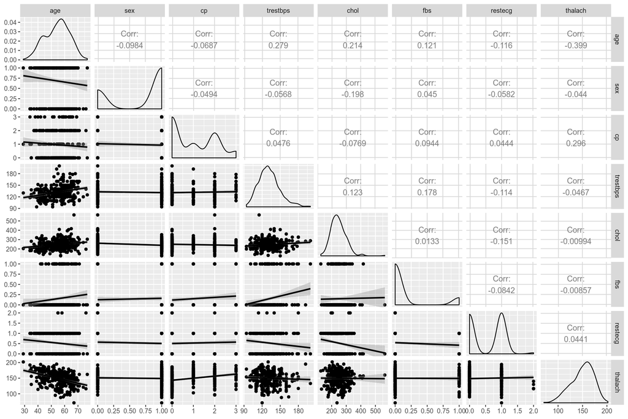

**Comentarios:** Para este caso se puede observar tanto correlacones negativas como positivas. A continuación analizaremos la relación entre algunas de las variables: - age-sex: En esta correlación se puede apreciar que hay una correlación neativa por lo que indica que ambas variables no camian juntas. - thalach-cp: Estas variables indican una correlación positiva, sin embargo dado su valor se puede ver que no es una correlación fuerte.

Cabe destacar que la correlación no necesariamente implica una causa, las variables A y B pueden subir y bajar juntas, o A puede aumentar a medida que B cae, pero no siempre es cierto que el aumento de un factor influye directamente en el aumento o la caída del otro. Ambos pueden ser causados por un tercer factor subyacente, como una variable C, o la relación aparente entre las variables podría ser una coincidencia.